# Preliminary Coho Escapement Estimates

Thomas Buehrens (tbuehrens@dfw.wa.gov) & Lisa Brown (lisa.brown@dfw.wa.gov)

Last Updated 01/21/2026.

## Background

Preliminary estimates of coho salmon escapement for the Washington State portion of the Lower Columbia ESU are needed in early February for run-reconstruction and forecasting purposes. This is challenging because coho have not yet completed their spawning so data is not yet done being collected, entered, QA/QC’d, or analyzed. As a result we developed two methods to predict final coho escapement using real-time data sets collected at a series of census count indicator locations in the Lower Columbia region. Method 1 is a multiple regression with auto-correlated error (via a spline on year). Method 2 uses a multivariate time series model (state-space log-normal random walk with drift). The models predict total (hatchery + wild) and wild coho abundance for the entire Washington State portion of the Lower Columbia ESU below Bonneville Dam. Population-level estimates are developed by multiplying the ESU-totals by the observed proportional contribution of populations to the ESU-total in the prior year. Model-averaged estimates are obtained by taking the arithmetic mean of the two models’ estimates with equal weight. Code and data for this preliminary escapement model as well as the final escapement model for the Washington State portion of the lower Columbia Coho ESU may be found in this [**repository**](https://github.com/tbuehrens/LCR_Coho_Escapement).

Indicator locations used in the model include: 1) Bonneville Dam (total counts) [**(link)**](http://www.cbr.washington.edu/dart/cs/php/rpt/adult_annual.php?sc=1&outputFormat=csv&proj=BON&startdate=1%2F1&enddate=12%2F31&run=) 2) Willamette Falls (total counts) [**(link)**](http://www.cbr.washington.edu/dart/cs/php/rpt/adult_annual.php?sc=1&outputFormat=csv&proj=WFF&startdate=1%2F1&enddate=12%2F31&run=%22) 3) Clackamas (wild counts at NF Dam) [**(link)**](https://portlandgeneral.com/about/fish-wildlife-habitats/fish-counts-fish-runs/clackamas-daily-fish-counts) 4) Washougal Hatchery (Type N counts of hatchery coho) [**(link)**](https://wdfw.wa.gov/fishing/management/hatcheries/escapement#weekly-reports)

## Setup

In the following section of code we will lode some external libraries necessary to make the code run. We will then specify the year of escapement we’d like to estimate and we will load the data used in the regression models. Links to these data sources are included in the code of this repository.

```r
#=========
# Packages
#=========
library(tidyverse)
library(rstan)
library(rstanarm)
library(mgcv)
library(ggplot2)
library(gridExtra)
library(brms)
library(kableExtra)
library(reshape2)


#=====================
#Specify Forecast Year
#=====================
f_year<-2025 #this is the year we want to predict prelim escapement for
results_folder<-"Results_2025-06-19" #trib estimate results to use.
wild_results<-"2010_2024_Coho_TRT_UM_ad.csv"
total_results<-"2010_2024_Coho_TRT_Adults.csv"
#===========================
#Data update links and files
#===========================
# LCR Totals = sum of medians by year Coho_TRT_Adults.csv
# LCR Wild = sum of medians by year Coho_TRT_UM_Ad.csv
# Bonneville Dam: http://www.cbr.washington.edu/dart/cs/php/rpt/adult_annual.php?sc=1&outputFormat=csv&proj=BON&startdate=1%2F1&enddate=12%2F31&run=
# Willamette Dam: "http://www.cbr.washington.edu/dart/cs/php/rpt/adult_annual.php?sc=1&outputFormat=csv&proj=WFF&startdate=1%2F1&enddate=12%2F31&run="
# Clackamas (early + late wild): https://portlandgeneral.com/about/fish-wildlife-habitats/fish-counts-fish-runs/clackamas-daily-fish-counts
# cowlitz ...open 10 year table https://www.mytpu.org/community-environment/fish-wildlife-environment/cowlitz-fish-report/
# washougal get the type N adult Hatchery total: https://wdfw.wa.gov/fishing/management/hatcheries/escapement#weekly-reports

LCR.total<-read_csv(file.path("results",results_folder,total_results))%>%
  group_by(Year)%>%
  summarize(LCR.total = sum(Median))
LCR.wild<-read_csv(file.path("results",results_folder,wild_results))%>%
  group_by(Year)%>%
  summarize(LCR.wild = sum(Median))
Bonneville.total<-read_csv("http://www.cbr.washington.edu/dart/cs/php/rpt/adult_annual.php?sc=1&outputFormat=csv&proj=BON&startdate=1%2F1&enddate=12%2F31&run=")%>%
  dplyr::select(Year,Bonneville.total=Coho)
Willamette.total<-read_csv("http://www.cbr.washington.edu/dart/cs/php/rpt/adult_annual.php?sc=1&outputFormat=csv&proj=WFF&startdate=1%2F1&enddate=12%2F31&run=")%>%
  dplyr::select(Year,Willamette.total=Coho)

dat<-read_csv("final data/cohocorr.csv")%>%
  left_join(Bonneville.total)%>%
  left_join(Willamette.total)%>%
  left_join(LCR.total)%>%
  left_join(LCR.wild)

dat%>%
  kbl(caption = 'Table 1. Counts of wild and hatchery coho from "indicator" locations used to develop preliminary escapement estimates of Lower Columbia Coho for the Washinton State portion of the Lower Columbia ESU below Bonneville Dam. Final estimates from previous years for wild coho (LCR.wild) and total hatchery and wild coho (LCR.total) are also included in the table',digits =0)%>%
  kable_classic(full_width = F, html_font = "Cambria")
```

Table 1. Counts of wild and hatchery coho from “indicator” locations used to develop preliminary escapement estimates of Lower Columbia Coho for the Washinton State portion of the Lower Columbia ESU below Bonneville Dam. Final estimates from previous years for wild coho (LCR.wild) and total hatchery and wild coho (LCR.total) are also included in the table

| Year | Clackamas.w | Cowlitz.barrier.total | Washougal.hatchery.late.h | Bonneville.total | Willamette.total | LCR.total | LCR.wild |
| --- | --- | --- | --- | --- | --- | --- | --- |
| 2010 | 1338 | 76876 | 2555 | 120915 | 20103 | 59464 | 25690 |
| 2011 | 1817 | 37791 | 1550 | 145299 | 3393 | 50360 | 26174 |
| 2012 | 1316 | 10538 | 1307 | 54968 | 6571 | 32748 | 23402 |
| 2013 | 2329 | 16602 | 2412 | 59610 | 18629 | 51455 | 27669 |
| 2014 | 8232 | 93072 | 11208 | 279733 | 18070 | 150936 | 96432 |
| 2015 | 1475 | 5718 | 816 | 37402 | 2651 | 23512 | 12603 |
| 2016 | 1338 | 24426 | 2469 | 42020 | 2559 | 54691 | 26664 |
| 2017 | 7078 | 20279 | 3304 | 75936 | 3041 | 51477 | 29222 |
| 2018 | 2882 | 10995 | 2400 | 40889 | 2557 | 42119 | 20023 |
| 2019 | 3765 | 15589 | 2202 | 73961 | 7454 | 55080 | 31188 |
| 2020 | 7469 | 39043 | 5047 | 121602 | 11800 | 83499 | 44208 |
| 2021 | 10194 | 56960 | 4237 | 243603 | 21108 | 94026 | 50250 |
| 2022 | 13099 | 64275 | 3469 | 168086 | 11260 | 83721 | 49287 |
| 2023 | 19141 | 32291 | 3203 | 132177 | 28636 | 62374 | 35210 |
| 2024 | 14326 | 58604 | 4510 | 185220 | 53466 | 97007 | 50971 |
| 2025 | 12215 | 51494 | 2929 | 161257 | 22521 | NA | NA |

```r
# dat<-dat%>%
#   mutate_at(.vars=c("Bonneville.total","Willamette.total", "Clackamas.w", "Cowlitz.barrier.total", "Washougal.hatchery.late.h"),.funs=function(x) c(scale(log(x))))
```

## Fit Model & Summarize Results (version 1)

```r
if(!file.exists("results/prelim/m1.RDS")){
  knots<-length(unique(dat$Year))-1
  m1<-stan_gamm4(log(LCR.wild) ~
               s(Year,bs="ps") +
               log(Bonneville.total) +
               log(Willamette.total) +
               log(Clackamas.w) +
               log(Cowlitz.barrier.total)+
               log(Washougal.hatchery.late.h),

               #prior=laplace(),
               prior=hs(
               ),

             data=dat%>%filter(Year<f_year),
             prior_intercept = cauchy(0,10),
             chains=4,
             cores=4,
             iter=10000,
             warmup=8000,
             control=list(adapt_delta=0.9995)
  )
  saveRDS(m1,file="results/prelim/m1.RDS")
}else{
    m1<-readRDS("results/prelim/m1.RDS")
  }
preds<-apply(posterior_predict(m1,newdata = data.frame(dat%>%dplyr::select(-c("LCR.wild","LCR.total"))),draws=1000),2,function(x) quantile(x,c(0.025,0.25,0.5,0.75,0.975)))
results<-data.frame(dat,exp(t(preds)))%>%
  mutate(Group="LCR.wild", Method = "Method 1")

p<-ggplot(results,aes(x=Year,y=LCR.wild))+
  geom_point(size=2)+
  ylim(0,NA)+
  geom_ribbon(aes(ymin=X2.5.,ymax=X97.5.),alpha=0.2)+
  geom_ribbon(aes(ymin=X25.,ymax=X75.),alpha=0.2)+
  geom_line(aes(x=Year,y=X50.))+
  geom_point(data=results%>%filter(Year==f_year),aes(x=Year,y=X50.),color="forestgreen",size=3)+
  facet_grid(~ Method)

if(!file.exists("results/prelim/m2.RDS")){
  knots<-length(unique(dat$Year))-1
  m2<-stan_gamm4(log(LCR.total) ~
                   s(Year,bs="ps") +
                   log(Bonneville.total) +
                   log(Willamette.total)+
                   log(Clackamas.w)+
                   log(Cowlitz.barrier.total) +
                   log(Washougal.hatchery.late.h),

                 #prior=laplace(),
                 prior=hs(
                 ),

                 data=dat%>%filter(Year<f_year),
                 prior_intercept = cauchy(0,10),
                 chains=4,
                 cores=4,
                 iter=10000,
                 warmup=8000,
                 control=list(adapt_delta=0.9995)
  )
  saveRDS(m2,file="results/prelim/m2.RDS")
}else{
    m2<-readRDS("results/prelim/m2.RDS")
  }
preds2<-apply(posterior_predict(m2,newdata = data.frame(dat%>%dplyr::select(-c("LCR.wild","LCR.total"))),draws=1000),2,function(x) quantile(x,c(0.025,0.25,0.5,0.75,0.975)))
results2<-data.frame(dat,exp(t(preds2)))%>%
  mutate(Group="LCR.total", Method = "Method 1")

p2<-ggplot(results2,aes(x=Year,y=LCR.total))+
  geom_point(size=2)+
  ylim(0,NA)+
  geom_ribbon(aes(ymin=X2.5.,ymax=X97.5.),alpha=0.2)+
  geom_ribbon(aes(ymin=X25.,ymax=X75.),alpha=0.2)+
  geom_line(aes(x=Year,y=X50.))+
  geom_point(data=results2%>%filter(Year==f_year),aes(x=Year,y=X50.),color="forestgreen",size=3)


results3<-bind_rows(results,results2)%>%
  as_tibble()%>%
  filter(Year==f_year)%>%
  dplyr::select(Year, Group, Method, cols=contains("x"))%>%
  rename(`2.5%`="cols1",`25%`="cols2",`50%`="cols3",`75%`="cols4",`97.5%`="cols5")



wild_pops<-read_csv(paste0("results/",results_folder,"/",wild_results))%>%
  as_tibble()%>%
  filter(Year == f_year-1)%>%
  mutate(Pop_prop = Median/sum(Median),
         Year = Year + 1,
         Group = "LCR.wild"
         )%>%
  dplyr::select(Year, Population, Pop_prop, Group)%>%
  left_join(results3)%>%
  mutate(`Preliminary Abundance Estimate` = `50%` * Pop_prop)%>%
  dplyr::select(Year, Population, Method, `Preliminary Abundance Estimate`)


total_pops<-read_csv(paste0("results/",results_folder,"/",total_results))%>%
  as_tibble()%>%
  filter(Year == f_year-1)%>%
  mutate(Pop_prop = Median/sum(Median),
         Year = Year + 1,
         Group = "LCR.total"
         )%>%
  dplyr::select(Year, Population, Pop_prop, Group)%>%
  left_join(results3)%>%
  mutate(`Preliminary Abundance Estimate` = `50%` * Pop_prop)%>%
  dplyr::select(Year, Population, Method, `Preliminary Abundance Estimate`)
```

## Fit Model & Summarize Results (version 2)

```r
dat2<-read_csv("final data/cohocorr.csv")%>%
  left_join(LCR.total)%>%
  left_join(LCR.wild)%>%
  left_join(Bonneville.total)%>%
  left_join(Willamette.total)%>%
  pivot_longer(cols=!Year,names_to = "Population",values_to = "Abundance")%>%
  filter(!is.na(Abundance))%>%
  mutate(popnum = as.numeric(as.factor(Population)),
         yearnum = Year-min(Year)+1
         )


standat<-list(
  run_estimation = 1,
  T = max(dat2$Year,na.rm = T)-min(dat2$Year,na.rm = T)+1,
  T_forward = 0,
  T_backward = 0,
  P = length(unique(dat2$Population)),
  n = dim(dat2)[1],
  N_obs = dat2$Abundance,
  pop_obs = dat2$popnum,
  year_obs = dat2$yearnum,
  N_0_med_prior = dat2%>%
    group_by(Population)%>%
    filter(Year == min(Year))%>%
    ungroup()%>%
    dplyr::select(Abundance)%>%
    unlist()
)

if(!file.exists("results/prelim/m3.RDS")){
  if(!file.exists("models/stan_prelim_model.RDS")){
    url  <- "https://raw.githubusercontent.com/tbuehrens/WDFW_SOS_Analysis/2022/models/model_mv_v3.stan"
    dest <- here::here("models/stan_prelim_model.stan")
    download.file(url, destfile = dest, method = "wininet", mode = "wb")
    model<-stan_model("models/stan_prelim_model.stan")
    saveRDS(model,"models/stan_prelim_model.RDS")
  }else{
    model<-readRDS("models/stan_prelim_model.RDS")
  }
  fit<-sampling(object = model,
               data = standat,
               chains = 4,
               cores = 4,
               warmup = 1000,
               iter = 2000,
               thin = 1,
               control= list(adapt_delta = 0.99)
               )
  saveRDS(fit,"results/prelim/m3.RDS")
}else{
  fit<-readRDS("results/prelim/m3.RDS")
}
results4<-melt(extract(fit)$N)%>%
  rename(yearnum=Var2,popnum=Var3,Abundance_fit=value)%>%
  group_by(yearnum,popnum)%>%
  summarise(Abundance_fit = quantile(Abundance_fit, c(0.025, 0.25, 0.5, 0.75,0.975)), q = c(0.025,0.25,0.5,0.75,0.975))%>%
  pivot_wider(id_cols=c(yearnum,popnum), names_from=q, values_from=Abundance_fit)%>%
  left_join(dat2%>%
              group_by(popnum)%>%
              summarise(Population=first(Population))
            )%>%
  left_join(dat2%>%
              group_by(yearnum)%>%
              summarise(Year=first(Year))
            )%>%
  left_join(dat2%>%
              dplyr::select(Year,Population,Abundance)
            )%>%
  mutate(Method = "Method 2")

p4<-ggplot(results4%>%filter(Population=="LCR.wild"),aes(x=Year,y=Abundance))+
  geom_point(size=2)+
  ylim(0,NA)+
  ylab("LCR.wild")+
  geom_ribbon(aes(ymin=`0.025`,ymax=`0.975`),alpha=0.2)+
  geom_ribbon(aes(ymin=`0.25`,ymax=`0.75`),alpha=0.2)+
  geom_line(aes(x=Year,y=`0.5`))+
  geom_point(data=results4%>%filter(Year==f_year, Population =="LCR.wild"),aes(x=Year,y=`0.5`),color="forestgreen",size=3)+
  facet_grid(~ Method)

p5<-ggplot(results4%>%filter(Population=="LCR.total"),aes(x=Year,y=Abundance))+
  geom_point(size=2)+
  ylim(0,NA)+
  ylab("LCR.total")+
  geom_ribbon(aes(ymin=`0.025`,ymax=`0.975`),alpha=0.2)+
  geom_ribbon(aes(ymin=`0.25`,ymax=`0.75`),alpha=0.2)+
  geom_line(aes(x=Year,y=`0.5`))+
  geom_point(data=results4%>%filter(Year==f_year, Population =="LCR.total"),aes(x=Year,y=`0.5`),color="forestgreen",size=3)


results4<-results4%>%
  ungroup()%>%
  filter(Year==f_year,Population %in% c("LCR.wild","LCR.total"))%>%
  dplyr::select(Year, Population, Method,cols=contains("."))%>%
  rename(Group = Population)%>%
  rename(`2.5%`="cols1",`25%`="cols2",`50%`="cols3",`75%`="cols4",`97.5%`="cols5")


wild_pops2<-read_csv(paste0("results/",results_folder,"/",wild_results))%>%
  as_tibble()%>%
  filter(Year == f_year-1)%>%
  mutate(Pop_prop = Median/sum(Median),
         Year = Year + 1,
         Group = "LCR.wild"
         )%>%
  dplyr::select(Year, Population, Pop_prop, Group)%>%
  left_join(results4)%>%
  mutate(`Preliminary Abundance Estimate` = `50%` * Pop_prop)%>%
  dplyr::select(Year, Population, Method, `Preliminary Abundance Estimate`)

total_pops2<-read_csv(paste0("results/",results_folder,"/",total_results))%>%
  as_tibble()%>%
  filter(Year == f_year-1)%>%
  mutate(Pop_prop = Median/sum(Median),
         Year = Year + 1,
         Group = "LCR.total"
         )%>%
  dplyr::select(Year, Population, Pop_prop, Group)%>%
  left_join(results4)%>%
  mutate(`Preliminary Abundance Estimate` = `50%` * Pop_prop)%>%
  dplyr::select(Year, Population, Method,`Preliminary Abundance Estimate`)
```

## Results

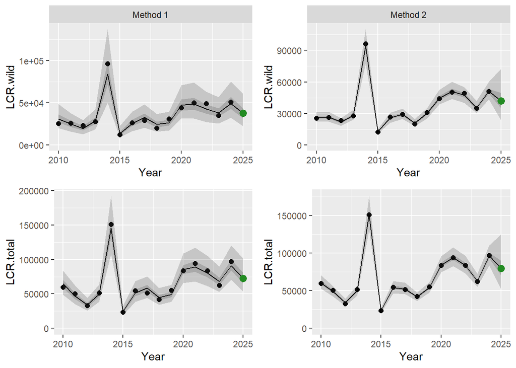

```r
grid.arrange(p, p4, p2, p5, ncol=2)
```

```r
ESU_results<-bind_rows(results3, results4)%>%
  pivot_longer(cols=contains("%"),names_to = "Quantile", values_to = "Abundance" )%>%
  group_by(Group, Quantile)%>%
  summarise(Method = "Mean", Year = mean(Year), Mean = mean(Abundance))%>%
  pivot_wider(names_from = Quantile, values_from = Mean)%>%
  bind_rows(results3)%>%
  bind_rows(results4)%>%
  arrange(Group,Method)

ESU_results%>%
  kbl(caption = paste0("Table 2. Posterior Quantiles of Preliminary Lower Columbia Coho Escapement (whole Washington portion of ESU below Bonneville Dam), ",f_year,"."),digits =0)%>%
  kable_classic(full_width = F, html_font = "Cambria")
```

Table 2. Posterior Quantiles of Preliminary Lower Columbia Coho Escapement (whole Washington portion of ESU below Bonneville Dam), 2025.

| Group | Method | Year | 2.5% | 25% | 50% | 75% | 97.5% |
| --- | --- | --- | --- | --- | --- | --- | --- |
| LCR.total | Mean | 2025 | 52908 | 67925 | 75861 | 85261 | 113212 |
| LCR.total | Method 1 | 2025 | 53572 | 65384 | 72278 | 80743 | 101573 |
| LCR.total | Method 2 | 2025 | 52243 | 70465 | 79444 | 89779 | 124851 |
| LCR.wild | Mean | 2025 | 22907 | 33624 | 39951 | 46580 | 66869 |
| LCR.wild | Method 1 | 2025 | 22259 | 32032 | 37887 | 43557 | 60982 |
| LCR.wild | Method 2 | 2025 | 23555 | 35216 | 42014 | 49604 | 72755 |

```r
Wild_Population_results<-bind_rows(wild_pops,wild_pops2)%>%
  group_by(Population)%>%
  summarise(Method = "Mean", Year = mean(Year), `Preliminary Abundance Estimate` = mean(`Preliminary Abundance Estimate`))%>%
  bind_rows(wild_pops)%>%
  bind_rows(wild_pops2)%>%
  pivot_wider(names_from = Method, values_from = `Preliminary Abundance Estimate`)%>%
  arrange(Population)

Wild_Population_results%>%
  kbl(caption = paste0("Table 3. Preliminary Lower Columbia Coho Escapement by NOAA Population: Wild ",f_year),digits =0)%>%
  kable_classic(full_width = F, html_font = "Cambria")
```

Table 3. Preliminary Lower Columbia Coho Escapement by NOAA Population: Wild 2025

| Population | Year | Mean | Method 1 | Method 2 |
| --- | --- | --- | --- | --- |
| Coweeman | 2025 | 1842 | 1747 | 1937 |
| EF Lewis | 2025 | 3255 | 3087 | 3423 |
| Elochoman, Skamokawa | 2025 | 1548 | 1468 | 1628 |
| Grays, Chinook | 2025 | 917 | 870 | 964 |
| Kalama | 2025 | 146 | 138 | 153 |
| Lower Cowlitz | 2025 | 8860 | 8402 | 9318 |
| Lower Gorge | 2025 | 1118 | 1061 | 1176 |
| Mill, Abernathy, Germany, Coal | 2025 | 3188 | 3023 | 3352 |
| NF Lewis | 2025 | 2728 | 2587 | 2869 |
| NF Toutle | 2025 | 1977 | 1875 | 2079 |
| SF Toutle | 2025 | 2068 | 1961 | 2174 |
| Salmon Creek | 2025 | 1288 | 1221 | 1354 |
| Tilton | 2025 | 673 | 638 | 708 |
| Upper Cowlitz and Cispus | 2025 | 9500 | 9009 | 9990 |
| Washougal | 2025 | 843 | 800 | 887 |

```r
Total_Population_results<-bind_rows(total_pops,total_pops2)%>%
  group_by(Population)%>%
  summarise(Method = "Mean", Year = mean(Year), `Preliminary Abundance Estimate` = mean(`Preliminary Abundance Estimate`))%>%
  bind_rows(total_pops)%>%
  bind_rows(total_pops2)%>%
  pivot_wider(names_from = Method, values_from = `Preliminary Abundance Estimate`)%>%
  arrange(Population)

Total_Population_results%>%
  kbl(caption = paste0("Table 4. Preliminary Lower Columbia Coho Escapement by NOAA Population: Total(Wild + Hatchery), ",f_year),digits =0)%>%
  kable_classic(full_width = F, html_font = "Cambria")
```

Table 4. Preliminary Lower Columbia Coho Escapement by NOAA Population: Total(Wild + Hatchery), 2025

| Population | Year | Mean | Method 1 | Method 2 |
| --- | --- | --- | --- | --- |
| Coweeman | 2025 | 2592 | 2469 | 2714 |
| EF Lewis | 2025 | 3436 | 3274 | 3598 |
| Elochoman, Skamokawa | 2025 | 2993 | 2851 | 3134 |
| Grays, Chinook | 2025 | 2744 | 2615 | 2874 |
| Kalama | 2025 | 362 | 345 | 379 |
| Lower Cowlitz | 2025 | 9189 | 8755 | 9624 |
| Lower Gorge | 2025 | 1623 | 1546 | 1699 |
| Mill, Abernathy, Germany, Coal | 2025 | 4178 | 3980 | 4375 |
| NF Lewis | 2025 | 10546 | 10048 | 11044 |
| NF Toutle | 2025 | 2779 | 2648 | 2911 |
| SF Toutle | 2025 | 2381 | 2269 | 2494 |
| Salmon Creek | 2025 | 1346 | 1282 | 1409 |
| Tilton | 2025 | 7843 | 7472 | 8213 |
| Upper Cowlitz and Cispus | 2025 | 22757 | 21682 | 23831 |
| Washougal | 2025 | 1092 | 1041 | 1144 |